# Exam 1

## Exam 1

#### Metainformation

1. | Tag | Value |
   | --- | --- |
   | `file` | Inferential_Statistics_vufsw-simple_linear_regression-0219-nl_vufsw-simple_linear_regression-0219-nl |
   | `name` | vufsw-simple linear regression-0219-nl |
   | `section` | inferential statistics/regression/simple linear regression |
   | `type` | schoice |
   | `solution` | FALSE, FALSE, TRUE, FALSE |
   | `Type` | interpretating graph |
   | `Program` | NA |
   | `Language` | dutch |
   | `Level` | statistical reasoning |

#### Question

   Een groep onderzoekers is geïnteresseerd in ervaren leeftijdsdiscriminatie en wil weten of ervaren leeftijdsdiscriminatie wordt beïnvloed door iemands leeftijd. De verwachting is dat zowel jongere als oudere mensen meer last hebben van leeftijdsdiscriminatie dan mensen van middelbare leeftijd. Ze analyseren gegevens uit de *European Social Survey* uit 2008/2009, die bestaat uit gegevens uit 28 landen.

   Voor een groep landen vinden ze de volgende waargenomen relatie tussen X en Y in onderstaande figuur.  
   Zijn dit op basis van deze figuur goede gegevens voor een enkelvoudige lineaire regressieanalyse?

   *(bron: Bratt, C., Abrams, D., Swift, H.J., Vauclair, C.-M., & Marques, S. (2018). Perceived Age Discrimination Across Age in Europe: From an Ageing Society to a Society for All Ages, Developmental Psychology, 54(1), 167-180.)*

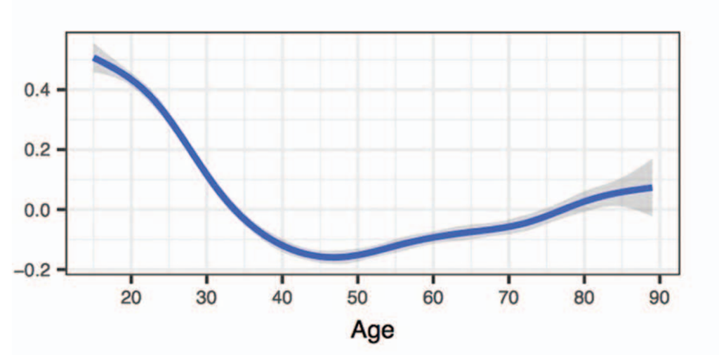

   1. **FALSE:** Nee, want uit deze grafiek blijkt dat de conditionele standaarddeviatie (s<sub>res</sub>) bij bepaalde leeftijden heel erg afwijkt van 0 (vooral bij jongere mensen).
   2. **FALSE:** Nee, omdat deze grafiek laat zien dat mensen van bepaalde leeftijden minder vertegenwoordigd zijn in deze steekproef dan mensen van andere leeftijden (vooral mensen van middelbare leeftijd zijn ondervertegenwoordigd).
   3. **TRUE:** Nee, want deze grafiek laat zien dat er geen lineaire relatie is tussen X en Y.
   4. **FALSE:** We kunnen dat niet zeggen op basis van alleen deze informatie; we kunnen de assumpties bij een regressie-analyse niet beoordelen op basis van deze gegevens.
   1. False
   2. False
   3. True
   4. False